# Alpha and Beta Schemes

Distributing a Beta version of your app to testers before submitting to the app store is a vital part of the submittal process for medium- to large-scale apps. Humon may be a small app now, but we are going to set up an Alpha and Beta configuration and scheme so as to follow best practices.

Every time you want to distribute a new build to Beta testers, you'll archive it and save it for ad hoc distribution. So what we're going to do is create a Beta scheme that we'll use every time we archive a Beta version of the app. We'll use the default Humon scheme for archiving the app's actual production version. The only differences between the new schemes will be the API endpoint (staging or production) we're hitting, the app name on the home screen, and the app's bundle ID.

Setting these manually is perfectly fine as well, but keeping separate configurations for Alpha, Beta, and production ensures that we never forget something important, like switching out the staging endpoint. The following steps will refer to creating the Beta scheme. They are exactly the same for creating an Alpha scheme.

### Setting Up the New Schemes

1. **Create the new configuration**

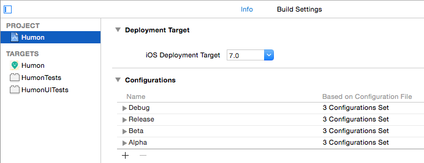

   Create the new configuration

   Select the Humon project and create a new configuration that's a duplicate of release, and call this new configuration Beta.
2. **Create the new scheme**

[figure not shown]

   Create the new scheme

   Create a new scheme that's a duplicate of the main Humon scheme. Call this scheme HumonBeta.

[figure not shown]

   Set the scheme's build configuration

   Set this scheme's run build configuration and archive build configuration to Beta.
3. **Automate the bundle identifier and display name**

[figure not shown]

   Automate the bundle identifier and display name

   Under "Info", change the Bundle identifier and the Bundle display name to include `${CONFIGURATION}`. `${CONFIGURATION}` evaluates to the name of the current build configuration.

   Now the name of the Beta app will display as HumonBeta and the bundle identifier will be com.thoughtbot.HumonBeta.
4. **Use the user-defined setting in a pre-processor macro.**

[figure not shown]

   Use the ROOT_URL in a pre-processor macro

   Under "Build Settings", search for preprocessor macros and add `ROOT_URL='@"yourProductionURL/"'` to the release and Beta configurations and `ROOT_URL='@"yourStagingURL/"'` for debug and Alpha configurations.
5. **Build the app using the new scheme.**

   The app's name should display as HumonBeta if everything has been configured correctly. In addition, you can now use `ROOT_URL` instead of a string literal everywhere you want to conditionally use your staging or production base URL.